# Do starting points matter?

Sensitivity test of pre-fire stand composition

Published

February 4, 2025

Modified

To compare my model output to exclosure data, I’d like to find data on the relationship between age and growth in stands that burned at high-severity.

Using iLand output like *fraction of crownkill* and *basal area consumed* didn’t work well for this question, since they both aggregate to the scale of the resource unit, and I kept ending up with trees that slipped through and weren’t killed in the fire, complicating the age-growth relationships. Instead, I’ve figured out how to take the stand output and look at the years before and after fire to find the resource unit IDs, and then I pull out the stand and sapling data for just those resource units.

I’m currently filtering by the following conditions:

- experienced 1 fire (and only 1 fire) in the 100 year simulation
- contained stands and saplings in the resource unit in the year before the fire (TSF = -1)
- had no trees or saplings in the year of the fire (TSF = 0)
- had no trees or saplings in the year following the fire (TSF = 1)

Here’s part* of the code I’m using to filter the output:

```r
 prefireStand <- stand %>%
    filter(TSF == -1 & # only TSF from year b4 fire
             count_ha > 0 & NPPabove_kg > 0 & # only rids with biomass b4 fire
             cohort_count_ha > 0 & cohort_basal_area > 0) %>%
    distinct(rid, .keep_all = TRUE) # find unique rids

  postfireStand <- stand %>%
    filter(TSF == 1 & count_ha == 0 & height_avg_m == 0 & NPPabove_kg == 0) %>%
    distinct(rid, .keep_all = TRUE)

  fireStand = stand %>%
    filter(TSF == 0 & count_ha == 0 & height_avg_m == 0 & NPPabove_kg == 0) %>%
    distinct(rid, .keep_all = TRUE)

  RID = postfireStand %>%
    filter(rid %in% prefireStand$rid, rid %in% fireStand$rid) %>%
    pull(rid) %>%
    unique()

  stand = stand %>%
    filter(rid %in% RID,
           cohort_id %in% postfireStand$cohort_id,
           TSF > 0,
           count_ha > 0) %>%
    select(c(year, ru, rid, species, count_ha,
             height_avg_m, dbh_avg_cm, basal_area_m2, TSF))
```

*Not included is the code that finds stands that burned once and only once, that’s a bit lengthy and I’m confident it’s working the way I want

Following that, I wanted to test out how much the prefire stand composition matters for the age growth relationships of different species.

# Sensitivity test

I’m using 3 approaches:

1. Not filtering by pre-fire composition at all
2. Selecting just the stands with a spruce importance value of 0.5 or more
3. Selecting just the stands with a spruce importance value of 0.9 or more

I tried a spruce importance value of 1, but in many of the replicates there weren’t any stands that met that criteria at all.

# How much does prefire stand composition matter?

All of the following is from runs of moose, hare, moose + hare and no moose/hare under historic climate, using the POLE-FM parameters and replicated 10x.

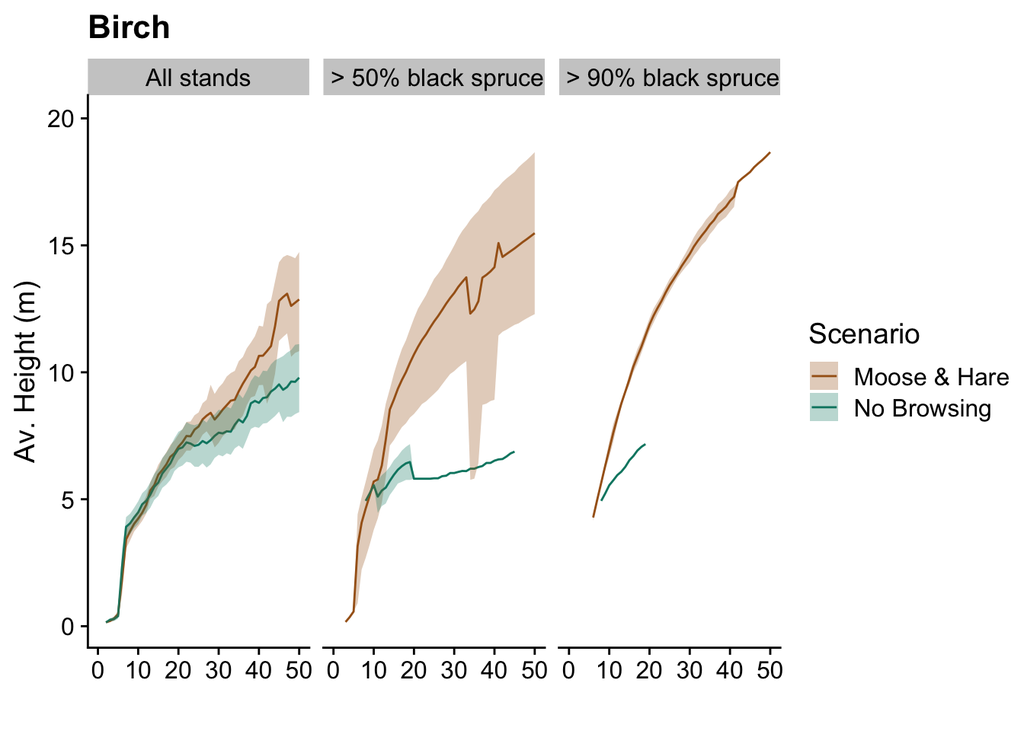

Looks like birch doesn’t persist in the later decades after fire in the stands that were mature black spruce prior to burning without herbivores. that seems counter-intuitive to me?

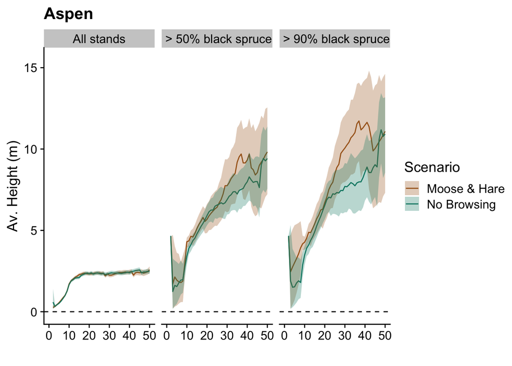

Aspen ends up much taller following fire in spruce stands, and it’s taller in the scenarios with browsing, which again, seems like the opposite of what I’d expect

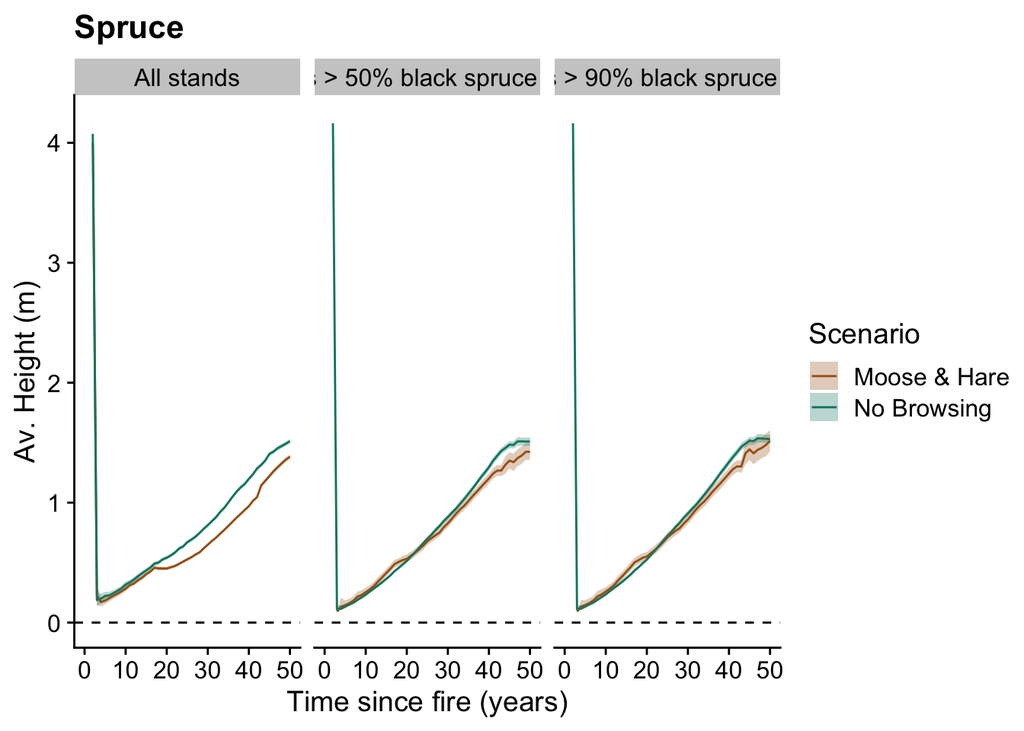

This looks like there’s some spruce that slipped through the filters - I don’t fully understand how spruce could have a height of 0 in TSF = 0 and TSF = 1, but appear at 4 meters in TSF = 2.

I’ll clip for now:

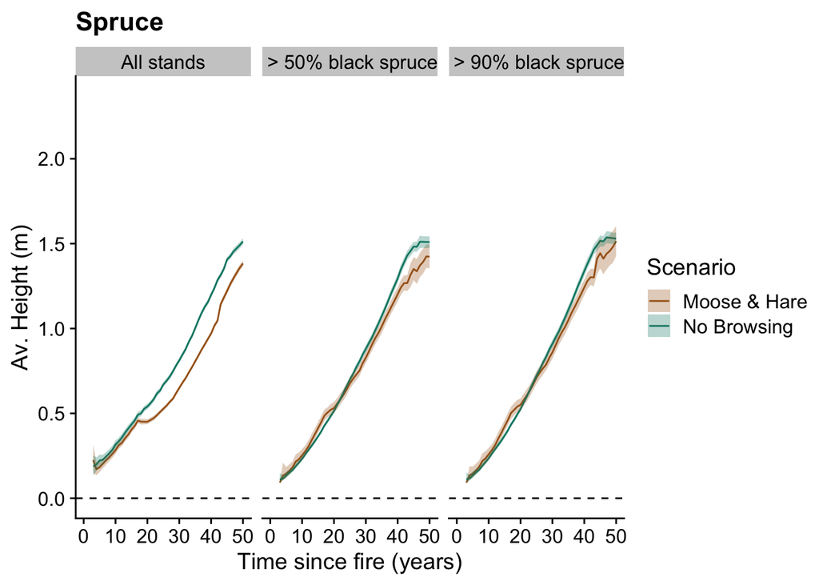

```r
data %>%
  filter(species == "Pima") %>%
  filter(Scenario != "Hare") %>%
  filter(Scenario != "Moose") %>%
  filter(TSF > 2) %>%
  ggplot() +
  geom_line(aes(x = TSF, y = height, col = Scenario)) +
  xlim(c(0,50)) +
  geom_ribbon(aes(x = TSF, ymin = low,
                    ymax = high, fill = Scenario),
              alpha = 0.3) +
    scale_color_manual(values = c("#a6611a", "#018571")) +
  geom_hline(yintercept = 0, linetype = "dashed") +
    labs(x = "Time since fire (years)", y = "Av. Height (m)",
         title ="Spruce") +
  scale_fill_manual(values = c("#a6611a", "#018571")) +
  facet_wrap(~filter)
```

Okay, so pre-fire stand conditions don’t matter much for spruce growth - makes sense, since it’s set up to grow steady/incrementally. But somehow it’s slightly taller in the scenario without browsing, even though neither herbivore actually browse black spruce. This is making me think I need to chat with Juha/Kati.

# Does the herbivore matter?

Here’s the same data but now broken out by herbivore:

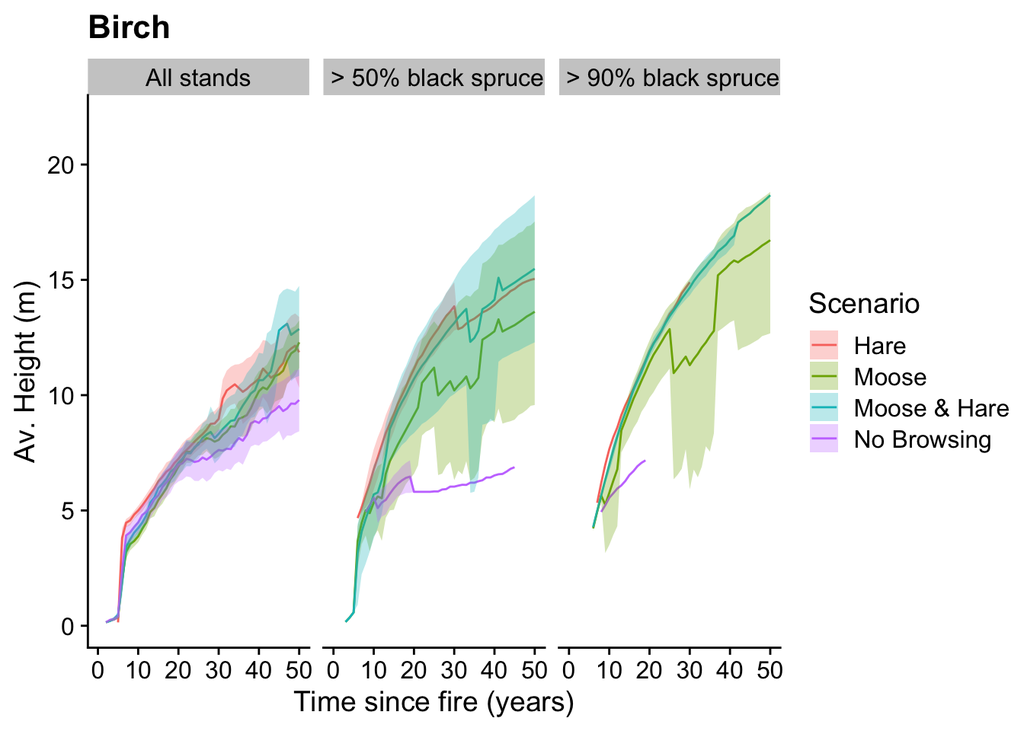

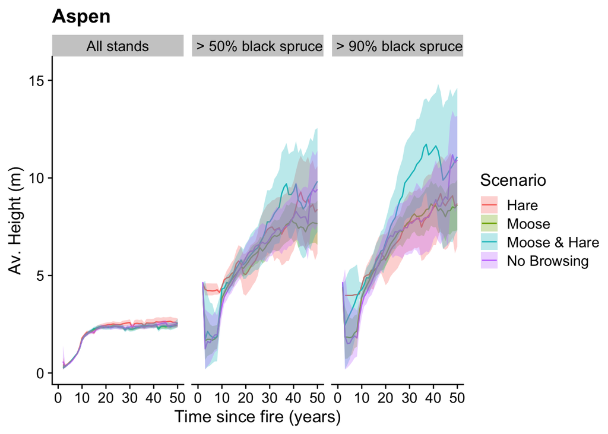

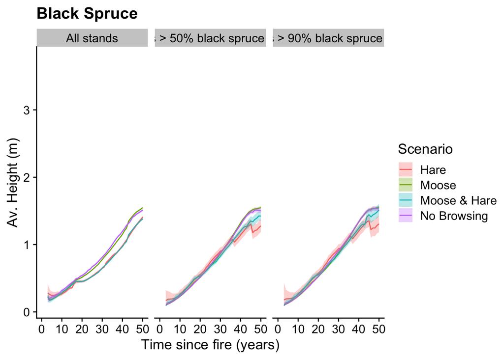

Overall, similar broad trends. Herbivore guild doesn’t differ too much in their impacts - the biggest thing I can pick out is that aspen is taller earlier when browsed by hare and not moose. Makes sense.